# How to work with Opendata real-time forecast on Earth Data Hub

### Surface temperature forecast in Rome

This notebook will provide you guidance on how to access and use the `s3://hedp/ecmwf-forecasts/opendata-oper-20231016T00.zarr` datset on Earth Data Hub.

The goal is to plot the surface temperature forecsat for October 16th.

## What you will learn:

- how to access and preview the dataset
- select and reduce the data
- plot the results

## Data access and preview

Xarray and Dask work together following a lazy principle. This means when you access and manipulate a Zarr store the data is in not immediately downloaded and loaded in memory. Instead, Dask constructs a task graph that represents the operations to be performed. A smart user will reduce the amount of data that needs to be downloaded before the computation takes place (e.g., when the `.compute()` or `.plot()` methods are called).

To preview the data, only the dataset metadata must be downloaded. Xarray does this automatically:

```python
import xarray as xr

# your `~/.netrc` file MUST contain your credentials for earthdatahub.com
#
# machine earthdatahub.com
#   login {your_username}
#   password {your_password}

ds = xr.open_dataset(
    "https://earthdatahub.destine.eu/stores/hedp/ecmwf-forecasts/opendata-oper-20231016T00.zarr",
    chunks={},
    engine="zarr",
    storage_options={"client_kwargs": {"trust_env": True}},
)
ds
```

```
<xarray.Dataset>
Dimensions:              (step: 65, latitude: 451, longitude: 900,
                          isobaricInhPa: 9)
Coordinates:
    depthBelowLandLayer  float64 ...
    entireAtmosphere     float64 ...
    heightAboveGround    float64 ...
  * isobaricInhPa        (isobaricInhPa) float64 1e+03 925.0 ... 200.0 50.0
  * latitude             (latitude) float64 90.0 89.6 89.2 ... -89.2 -89.6 -90.0
  * longitude            (longitude) float64 -180.0 -179.6 ... 179.2 179.6
  * step                 (step) timedelta64[ns] 00:00:00 ... 10 days 00:00:00
    surface              float64 ...
    time                 datetime64[ns] ...
    valid_time           (step) datetime64[ns] dask.array<chunksize=(65,), meta=np.ndarray>
Data variables: (12/16)
    10u                  (step, latitude, longitude) float32 dask.array<chunksize=(65, 41, 45), meta=np.ndarray>
    10v                  (step, latitude, longitude) float32 dask.array<chunksize=(65, 41, 45), meta=np.ndarray>
    2t                   (step, latitude, longitude) float32 dask.array<chunksize=(65, 41, 45), meta=np.ndarray>
    d                    (step, isobaricInhPa, latitude, longitude) float32 dask.array<chunksize=(65, 9, 41, 45), meta=np.ndarray>
    gh                   (step, isobaricInhPa, latitude, longitude) float32 dask.array<chunksize=(65, 9, 41, 45), meta=np.ndarray>
    q                    (step, isobaricInhPa, latitude, longitude) float32 dask.array<chunksize=(65, 9, 41, 45), meta=np.ndarray>
    ...                   ...
    t                    (step, isobaricInhPa, latitude, longitude) float32 dask.array<chunksize=(65, 9, 41, 45), meta=np.ndarray>
    tcwv                 (step, latitude, longitude) float32 dask.array<chunksize=(65, 41, 45), meta=np.ndarray>
    tp                   (step, latitude, longitude) float32 dask.array<chunksize=(65, 41, 45), meta=np.ndarray>
    u                    (step, isobaricInhPa, latitude, longitude) float32 dask.array<chunksize=(65, 9, 41, 45), meta=np.ndarray>
    v                    (step, isobaricInhPa, latitude, longitude) float32 dask.array<chunksize=(65, 9, 41, 45), meta=np.ndarray>
    vo                   (step, isobaricInhPa, latitude, longitude) float32 dask.array<chunksize=(65, 9, 41, 45), meta=np.ndarray>
Attributes:
    Conventions:             CF-1.7
    GRIB_centre:             ecmf
    GRIB_centreDescription:  European Centre for Medium-Range Weather Forecasts
    GRIB_edition:            2
    GRIB_subCentre:          0
    history:                 2023-10-16T10:59 GRIB to CDM+CF via cfgrib-0.9.1...
    institution:             European Centre for Medium-Range Weather Forecasts
```

## Working with data

Datasets on EDH are typically very large and remotely hosted. Typical use imply a selection of the data followed by one or more reduction steps to be performed in a local or distributed Dask environment.

The structure of a workflow that uses EDH data looks like this:

1. data selection
2. (optional) data reduction
3. (optional) visualization

## Rome 2 metre temperature forecast

### 1. Data selection

We select the 2 metre temperature variable from the dataset and we convert it form `K` to `°C`. Forecast steps are given in `ns`, we convert it to `h`.

```python
t2m = ds["2t"] - 273.15
t2m.attrs["units"] = "C"
t2m["step"] = t2m.step.astype('datetime64[ns]').astype('float64') / 1e9 / 3600
t2m
```

```
<xarray.DataArray '2t' (step: 65, latitude: 451, longitude: 900)>
dask.array<sub, shape=(65, 451, 900), dtype=float32, chunksize=(65, 41, 45), chunktype=numpy.ndarray>
Coordinates:
    depthBelowLandLayer  float64 ...
    entireAtmosphere     float64 ...
    heightAboveGround    float64 ...
  * latitude             (latitude) float64 90.0 89.6 89.2 ... -89.2 -89.6 -90.0
  * longitude            (longitude) float64 -180.0 -179.6 ... 179.2 179.6
    surface              float64 ...
    time                 datetime64[ns] ...
    valid_time           (step) datetime64[ns] dask.array<chunksize=(65,), meta=np.ndarray>
  * step                 (step) float64 0.0 3.0 6.0 9.0 ... 228.0 234.0 240.0
Attributes:
    units:    C
```

We select then the closest point to Rome:

```python
t2m_Rome = t2m.sel(**{"latitude": 41.9, "longitude": 12.5}, method="nearest")
t2m_Rome
```

```
<xarray.DataArray '2t' (step: 65)>
dask.array<getitem, shape=(65,), dtype=float32, chunksize=(65,), chunktype=numpy.ndarray>
Coordinates:
    depthBelowLandLayer  float64 ...
    entireAtmosphere     float64 ...
    heightAboveGround    float64 ...
    latitude             float64 42.0
    longitude            float64 12.4
    surface              float64 ...
    time                 datetime64[ns] ...
    valid_time           (step) datetime64[ns] dask.array<chunksize=(65,), meta=np.ndarray>
  * step                 (step) float64 0.0 3.0 6.0 9.0 ... 228.0 234.0 240.0
Attributes:
    units:    C
```

At this point, no data has been downloaded yet, nor loaded in memory. However, the selection is small enough to call `.compute()` on it. This will trigger the download of data from EDH and load it in memory.

We can mesure the time it takes:

```python
%%time

t2m_Rome = t2m_Rome.compute()
```

```
CPU times: user 89 ms, sys: 15.7 ms, total: 105 ms
Wall time: 1.87 s
```

The data was very small, this didn't take long.

### 2. Visualization

Now that the data is loaded in memory, we can easily plot the temperature forecast.

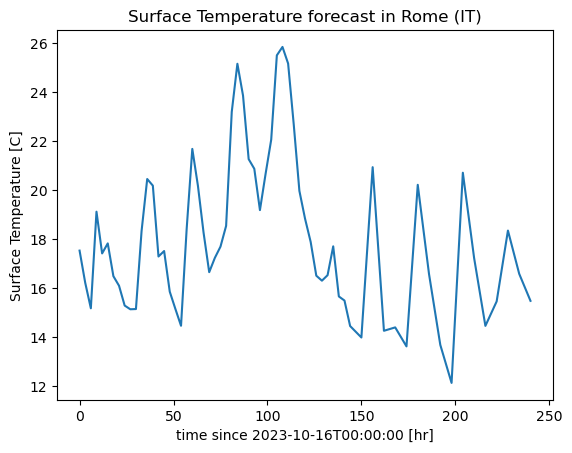

```python
import matplotlib.pyplot as plt
import numpy as np

t2m_Rome.plot()
plt.title("Surface Temperature forecast in Rome (IT)")
plt.ylabel("Surface Temperature [C]")
reference_time = np.datetime_as_string(t2m_Rome.time.values)
plt.xlabel(f"time since {reference_time[:-10]} [hr]")
plt.show()
```